# Vsiljeno nihanje nihajnega kroga

### vaja 43, mar. 2021

## UVOD

V električnem nihajnem krogu se pri nihanju izmenjujeta električna energija kondenzatorja in magnetna energija tuljave. Zaradi dušenja (upora žic, notranjega upora komponent) nihanje po določenem času izzveni. Če ga vzbujamo s sinusno napetostjo, nihanje ne izzveni, pač pa niha z amplitudo in faznim zamikom (izmerimo z osciloskopom), ki je odvisna od frekvence vzbujanja in je največja, ko je sistem v resonanci ($\nu_{vzbujanja} = \nu_0 $).

$ \nu_0 = \frac{1}{2 \pi \sqrt{LC}}$

## NALOGA

Izmeriti resonančno krivuljo sistema RLC pri različnih stopnjah dušenja in izmeriti nekaj Lisajoujevih figur.

## MERITVE

$\nu = (560 \pm 5)\ kHz$

Na 1. kanalu osciloskopa merimo vhodno napetost, na 2. pa odziv sistema. Napetosti preberemo z uporabo vdelanih funkcij voltmetra (njihovo napako zanemarimo). Izmerjene napetosti so peak-to-peak; prave amplitude torej dobimo tako, da meritve delimo z 2. Izmerimo tudi število razdelkov na kondenzatorju, ki jih nato pretvorimo v kapaciteto s pomočjo spodnje umeritvene krivulje.

```python
%matplotlib inline
import warnings
warnings.filterwarnings('ignore')
from vaja43 import *
print(displaydata.to_string())
```

```
    R [Ω]  U1 (pp) [V]  U2 (pp) [mV]  št. razdelkov
0       0         4.72            88           50.0
1       0         4.72           104          100.0
2       0         4.72           128          120.0
3       0         4.72           216          150.0
4       0         4.72           352          160.0
5       0         4.72          1110          170.0
6       0         4.72           512          165.0
7       0         4.72           408          162.5
8       0         4.72           200          199.7
9       0         4.72           360          195.0
10      0         4.72           560          185.0
11      0         4.72          2970          173.0
12      0         4.72          4250          174.0
13      0         4.72          4300          175.0
```

[output cut: 52 more lines]

### Umeritvena krivulja kondenzatorja

Polinom 3. reda da dobro aproksimacijo relacije med številom razdelkov in kapaciteto.

```python
display(ufig)
```

[figure not shown]

## OBDELAVA PODATKOV

Napetost $U_2$ (odziv sistema) pri resonančni krivulji normaliziramo z $U_1$ (vhodno napetostjo): $u=\frac{U_2}{U_1}$ Resonančna krivulja ima obliko $$ u(\frac{\nu}{\nu_0}) = \frac{A}{\sqrt{(1-\frac{\nu}{\nu_0})^2 + B^2 (\frac{\nu}{\nu_0})^2}}$$

Najprej pomerimo odvisnost $u(C)$ brez dušenja, da ocenimo induktivnost tuljave. $$u(C) = u(\nu 2 \pi \sqrt{LC})$$ Ob poznavanju C, u in $\nu$ s fitanjem določimo $L = L_0$, A in B.

```python
print('L_0 =', L_0_ufloat, 'H')
```

```
L_0 = 0.00012030+/-0.00000005 H
```

Sedaj lahko narišemo resonančne krivulje:

```python
display(fig2)
```

[figure not shown]

### Lisajoujeve figure

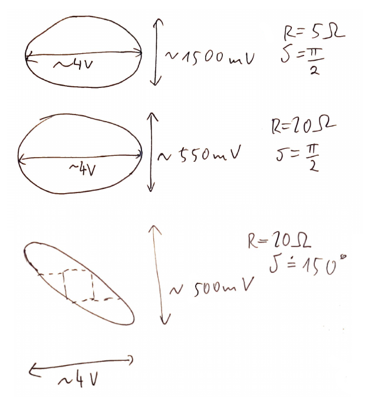

```python
from IPython.display import Image
Image(filename='lis_fig.png')
```